# Python API to www.argovis.com

For over a decade, the [ARGO](http://www.argo.ucsd.edu/index.html) program has provided temperature, salinity and pressure data (T/S/P) on a global scale for depths as far as 2000 dbar, with unprecedented spatial and temporal resolution and no seasonal bias. Close to two million profiles have been collected and made publicly available on Argo’s Global Data Assembly Centres (GDACs) on FTP servers. Unfortunately, online tools for selection and visualization of this big data set are limited slow to access.

In response, a webapp www.argovis.com attempts to improve data access. Overall, this website offers seamless navigation of the Argo dataset. Argo now has a maintainable, scalable, and portable tool written with representational state transfer (REST) architecture. RESTful design offers us the opportunity to feature cloud computing applications; chiefly, map comparison from existing gridded Argo products, as well as parameter estimation such as basin mean T/S/P.

The following code is an interface to argovis.com. HTTP 'get' requests access the web app's database, similar to a browser; however, there is no HTML or javascript. Essentially, this interface is used to query the same database that builds the website. The idea behind this approach is that we no longer rely on the browser to handle queries.

This script will guide a python user to:

1. Query a specific profile its id, designated by its platform (WMO) number with its cycle number, connected by an underscore. For example '3900737_9'
2. Query a specified platform by number. Example '3900737'.
3. Query profiles within a given shape, date range, and pressure range.
4. Plot query results
5. Create time series given for a selection and set of dates.

Firstly, following libraries are called

```python
import requests
import pandas as pd
import numpy as np
from plotly.offline import download_plotlyjs, init_notebook_mode, iplot
import plotly.graph_objs as go
init_notebook_mode()
import cmocean
import matplotlib.pylab as plt
from scipy.interpolate import griddata
from datetime import datetime
import pdb
%matplotlib inline
```

# 1. Get A Profile

The requests library handles HTTP get requests. If the message is received and the profile exists Argovis will return a JSON object. Python casts a JSON object as a native dictionary type.

```python
def get_profile(profile_number):
    resp = requests.get('http://www.argovis.com/catalog/profiles/'+profile_number)
    # Consider any status other than 2xx an error
    if not resp.status_code // 100 == 2:
        return "Error: Unexpected response {}".format(resp)
    profile = resp.json()
    return profile
```

The pandas dataframe object is better suited to handle manipulations. Essentially it is a spreadsheet.

```python
profileDict = get_profile('3900737_279')
profileDf = pd.DataFrame(profileDict['measurements'])
profileDf['cycle_number'] = profileDict['cycle_number']
profileDf['profile_id'] = profileDict['_id']
profileDf.head()
```

|  | pres | pres_qc | psal | psal_qc | temp | temp_qc | cycle_number | profile_id |
| --- | --- | --- | --- | --- | --- | --- | --- | --- |
| 0 | 4.400000 | 1 | 35.451 | 1 | 27.165001 | 1 | 279 | 3900737_279 |
| 1 | 10.000000 | 1 | 35.452 | 1 | 27.063000 | 1 | 279 | 3900737_279 |
| 2 | 16.900000 | 1 | 35.452 | 1 | 27.055000 | 1 | 279 | 3900737_279 |
| 3 | 23.699999 | 1 | 35.452 | 1 | 27.048000 | 1 | 279 | 3900737_279 |
| 4 | 30.900000 | 1 | 35.451 | 1 | 27.046000 | 1 | 279 | 3900737_279 |

Through pandas, we can save this as a csv for storage.

```python
profileDf.to_csv('profile.csv')
```

# 2. Get A Platform

A platform consists of a list of profiles. An additional function 'parse_into_df' appends each profile to one data frame.

```python
def get_platform_profiles(platform_number):
    resp = requests.get('http://www.argovis.com/catalog/platforms/'+platform_number)
    # Consider any status other than 2xx an error
    if not resp.status_code // 100 == 2:
        return "Error: Unexpected response {}".format(resp)
    platformProfiles = resp.json()
    return platformProfiles

def parse_into_df(profiles):
    #initialize dict
    meas_keys = profiles[0]['measurements'][0].keys()
    df = pd.DataFrame(columns=meas_keys)
    for profile in profiles:
        profileDf = pd.DataFrame(profile['measurements'])
        profileDf['cycle_number'] = profile['cycle_number']
        profileDf['profile_id'] = profile['_id']
        profileDf['lat'] = profile['lat']
        profileDf['lon'] = profile['lon']
        profileDf['date'] = profile['date']
        df = pd.concat([df, profileDf])
    return df
```

```python
platformProfiles = get_platform_profiles('3900737')
platformDf = parse_into_df(platformProfiles)
print('number of measurements {}'.format(platformDf.shape[0]))
```

```
number of measurements 19923
```

```python
platformDf.head()
```

|  | cycle_number | date | lat | lon | pres | pres_qc | profile_id | psal | psal_qc | temp | temp_qc |
| --- | --- | --- | --- | --- | --- | --- | --- | --- | --- | --- | --- |
| 0 | 72.0 | 2011-07-24T11:52:00.001Z | -5.038 | -111.012 | 4.800000 | 1 | 3900737_72 | 35.391998 | 1 | 24.448000 | 1 |
| 1 | 72.0 | 2011-07-24T11:52:00.001Z | -5.038 | -111.012 | 9.800000 | 1 | 3900737_72 | 35.391998 | 1 | 24.461000 | 1 |
| 2 | 72.0 | 2011-07-24T11:52:00.001Z | -5.038 | -111.012 | 16.900000 | 1 | 3900737_72 | 35.391998 | 1 | 24.461000 | 1 |
| 3 | 72.0 | 2011-07-24T11:52:00.001Z | -5.038 | -111.012 | 23.700001 | 1 | 3900737_72 | 35.391998 | 1 | 24.462999 | 1 |
| 4 | 72.0 | 2011-07-24T11:52:00.001Z | -5.038 | -111.012 | 30.600000 | 1 | 3900737_72 | 35.391998 | 1 | 24.462000 | 1 |

Dataframes can handle large arrays efficiently, thanks to the underlying numpy library. Pandas allows for easy and quick computations, such as taking the mean of the measurements.

```python
platformDf[['pres', 'psal', 'temp']].mean(0)
```

```
pres    537.339862
psal     34.861437
temp     12.055308
dtype: float64
```

# 3. Get A Selection

A user quickly accesses profiles and platform data by searching the FTP site or using tools already in existence. Argovis goes one step further by querying with criteria such as:

- start date
- end date
- pressure range
- polygon of latitude-longitude coordinates

The code below allows pressure to be optional.

```python
def get_selection_profiles(startDate, endDate, shape, presRange=None):
    baseURL = 'http://www.argovis.com/selection/profiles'

    startDateQuery = '?startDate=' + startDate
    endDateQuery = '&endDate=' + endDate
    shapeQuery = '&shape='+shape
    if not presRange == None:
        pressRangeQuery = '&presRange=' + presRange
        url = baseURL + startDateQuery + endDateQuery + pressRangeQuery + shapeQuery
    else:
        url = baseURL + startDateQuery + endDateQuery + shapeQuery
    resp = requests.get(url)
    # Consider any status other than 2xx an error
    if not resp.status_code // 100 == 2:
        return "Error: Unexpected response {}".format(resp)
    selectionProfiles = resp.json()
    return selectionProfiles


startDate='2017-9-15'
endDate='2017-10-31'
# shape should be nested array with lon, lat coords.
shape = '[[[-18.6,31.7],[-18.6,37.7],[-5.9,37.7],[-5.9,31.7],[-18.6,31.7]]]'
presRange='[0,30]'
```

```python
selectionProfiles = get_selection_profiles(startDate, endDate, shape, presRange)
if len(selectionProfiles) > 0:
    selectionDf = parse_into_df(selectionProfiles)
```

Note that we probably should spatially average, but you get the picture!

```python
selectionDf[['pres', 'psal', 'temp']].mean(0)
```

```
pres    13.743210
psal    36.697441
temp    22.476747
dtype: float64
```

# 4. Plotting results

Argovis's plotting capabilities are limited to what is coded in javascript. There are many plotting libraries out there, but in this example we can create plots on our machine, thereby allowing customization.

```python
def matplotlib_to_plotly(cmap, pl_entries):
    h = 1.0/(pl_entries-1)
    pl_colorscale = []

    for k in range(pl_entries):
        C = list(map(np.uint8, np.array(cmap(k*h)[:3])*255))
        pl_colorscale.append([k*h, 'rgb'+str((C[0], C[1], C[2]))])

    return pl_colorscale
thermal_scl = matplotlib_to_plotly(cmocean.cm.thermal, 9)
haline_scl = matplotlib_to_plotly(cmocean.cm.haline, 9)
```

```python
def makeScatterTrace(df, colorValue, scl, units):
    trace = go.Scatter(
            x = df['profile_id'],
            y = df['pres'],
            text = df['temp'],
            mode = 'markers',
            marker = dict(
                size = 8,
                opacity = 0.8,
                autocolorscale = False,
                symbol = 'dot',
                line = dict(
                    width=0,
                    color='rgba(102, 102, 102)'),
                colorscale = scl,
                cmin = df['temp'].min(),
                color = df['temp'].round(1),
                cmax = df['temp'].max(),
                colorbar=dict(
                    title=units)
                )
        )
    return trace

def makeLayout(xlabel, ylabel, chartTitle):
    layout = dict(
            autosize=False,
            width=950,
            height=500,
            hovermode=True,
            title = chartTitle,
            titlefont=dict(
                size=16,
                ),
            colorbar = True,
            xaxis=dict(
                title=xlabel,
                titlefont=dict(
                    size=16
                    ),
                    tickfont=dict(
                        size = 12
                    ),
                showticklabels=False,
                showgrid=False,
                zeroline=False,
                showline=False,
                ),
            yaxis=dict(
                title=ylabel,
                autorange='reversed',
                titlefont=dict(
                    size=16
                    ),
                tickfont=dict(
                    size = 12
                    ),
                showticklabels=True,
                showgrid=False,
                zeroline=False,
                showline=False,
                ),
            )
    return layout

temp_trace = makeScatterTrace(selectionDf, 'temp', thermal_scl, 'Celcius')
temp_layout = makeLayout('profile_id', 'Pressure [dbar]', 'Temperature profiles of selection')
fig1 = dict( data=[temp_trace], layout=temp_layout)
plot1 = iplot(fig1, validate=False)
```

[interactive chart not shown]

Contour plots created by interpolation can be created using this data. Below is an example one such field that uses cubic interpolation. I also included an xkcd style to demonstrate customization capabilities.

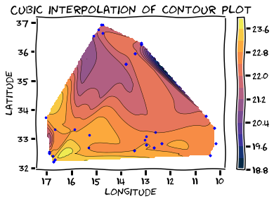

```python
def contourPlot(df):
    fig = plt.figure()
    axes = plt.axes()
    xi = np.linspace(df['lon'].min(),df['lon'].max(),100)
    yi = np.linspace(df['lat'].min(),df['lat'].max(),100)

    x = df['lon'].values
    y = df['lat'].values
    z = df['temp'].values
    zi = griddata((x, y), z, (xi[None,:], yi[:,None]), method='cubic')
    CS = plt.contour(xi,yi,zi,15,linewidths=0.5,colors='k')
    CS = plt.contourf(xi,yi,zi,15,cmap=cmocean.cm.thermal)
    axes.scatter(x,y,marker='o',c='b',s=5)
    axes.set_title('Cubic interpolation of contour plot')

    axes.set_ylabel('latitude')
    axes.set_xlabel('longitude')
    cbar = fig.colorbar(CS, cmap = cmocean.cm.thermal)
    return fig
with plt.xkcd():
    # This figure will be in XKCD-style
    fig1 = contourPlot(selectionDf)
```

# 5. Time series

Stacking selection query averages Suppose that we average the temperature o selection query of Gibralter single value, and we give this value a time index. Repeating this process with an array of date ranges, we can create a time series. Just a disclaimer, this selection should be spatially averaged, but is left out; this is only a demonstration.

```python
def get_dates_set(period=12):
    n_rows = int(np.floor(365/period))
    datesSet = []
    for year in range(2004, 2018):
        yearSet = np.array_split(pd.date_range(str(year)+'-01-01', str(year)+'-12-31'), n_rows)
        datesSet = datesSet + yearSet
    keepEnds = lambda x: [x[0].strftime(format='%Y-%m-%d'), x[-1].strftime(format='%Y-%m-%d')]
    datesSet = list(map(keepEnds, datesSet))
    return datesSet

def get_ocean_time_series(seriesStartDate, seriesEndDate, shape, presRange='[0, 30]'):
    """Queries argovis database over long time scales but over one shape.
    shape should have a radius of no more than a few degrees.
    Pressure range should about 10-50 dbar.
    """

    selectionProfiles = get_selection_profiles(seriesStartDate, seriesEndDate, shape, presRange)
    if len(selectionProfiles) == 0:
        return
    df = parse_into_df(selectionProfiles)

    #provide a time index for date ranges
    datesSet = get_dates_set(12)
    dateFormat = '%Y-%m-%dT%H:%M:%S.%fZ'
    df['date'] =  pd.to_datetime(df['date'], format=dateFormat)
    for idx, dates in enumerate(datesSet):
        startDate = datetime.strptime(dates[0], '%Y-%m-%d')
        endDate = datetime.strptime(dates[1], '%Y-%m-%d')
        try:
            if df[ (df['date'] < endDate) & (df['date'] > startDate)].shape[0] > 0: # sometimes there aren't any profiles at certain depth intervals
                df.loc[ (df['date'] <= endDate) & (df['date'] > startDate), 'tIndex'] = idx
                df.loc[ (df['date'] <= endDate) & (df['date'] > startDate), 'startDate'] = startDate
                df.loc[ (df['date'] <= endDate) & (df['date'] > startDate), 'endDate'] = endDate
        except ValueError:
            pdb.set_trace()
            df[ (df['date'] < startDate) & (df['date'] > endDate)].shape[0]

    df = df[np.isfinite(df['tIndex'])]
    #df.dropna(axis=1, how='any', inplace=True)
    #group and aggregate over tIndex
    tsDf = pd.DataFrame()
    grouped = df.groupby('tIndex')

    for tdx, group in grouped:
        nMeas = group.shape[0]
        if nMeas == 0:
            continue
        try:
            aggMean = group[['temp', 'psal']].mean()
            aggStd = group[['temp', 'psal']].std()
        except KeyError:
            pdb.set_trace()
            grouped.columns
        startDate = group['startDate'].values[0]
        endDate = group['endDate'].values[0]
        tsDf.set_value(tdx, 'tempMean', aggMean.temp)
        tsDf.set_value(tdx, 'psalMean', aggMean.psal)
        tsDf.set_value(tdx, 'tempStd', aggStd.temp)
        tsDf.set_value(tdx, 'psalStd', aggStd.psal)
        tsDf.set_value(tdx, 'startDate', startDate)
        tsDf.set_value(tdx, 'endDate', endDate)
        tsDf.set_value(tdx, 'nProf', nMeas)
    return tsDf
```

```python
tsDf = get_ocean_time_series('2004-01-01', '2017-12-31', shape, presRange='[0, 30]')
```

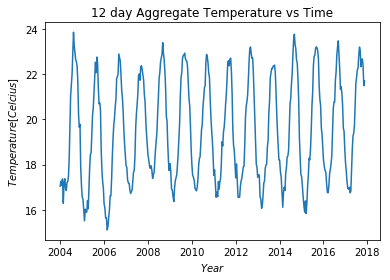

```python
fig = plt.figure(999)
axes = plt.axes()
temp = tsDf['tempMean'].values
time = tsDf['startDate'].values
axes.plot(time, temp)
axes.set_title(r'12 day Aggregate Temperature vs Time')
axes.set_ylabel(r'$Temperature [Celcius]$')
axes.set_xlabel(r'$Year$')
```

# Conclusion

The three main functions described in sections 1, 2, and 3 can be written in a number or languages, such as R or Matlab. This project is still new, and will continue to evolve and improve.